# R Notebook

For these analysis, we will be taking a further look into model selection. We have seen the anova method and how that plays into choosing between models. The anova method comes with limitations however, first and for most the two models that are being compared are usually a main model and a submodel. The main model has everything that the sub model has plus more. The sub model only holds several of the predictors that the main model has. As you can see, this limits us when it comes to comparing models because what if we wanted to compare two completely different models with a different set of predictors? Well, we have several methods. For prediction purposes, we will do the k-fold cross validation method to see which of our two models predict the best. We compare the residual sum of square or the mean square error to figure out which of our models predicted the best.

```r
library(alr4)
library(lmtest)
library(foreach)
library(doParallel)

head(MinnLand)
```

|  | acrePrice | region | improvements | year | acres | tillable | financing | crpPct | productivity | yearF |
| --- | --- | --- | --- | --- | --- | --- | --- | --- | --- | --- |
| 1 | 766 | Northwest | 0 | 2002 | 82 | 94 | title_transfer | 0 | NA | 2002 |
| 2 | 733 | Northwest | 0 | 2003 | 30 | 63 | title_transfer | 0 | NA | 2003 |
| 3 | 850 | Northwest | 4 | 2002 | 150 | 47 | title_transfer | 0 | NA | 2002 |
| 4 | 975 | Northwest | 0 | 2003 | 160 | 86 | title_transfer | 0 | NA | 2003 |
| 5 | 886 | Northwest | 62 | 2002 | 90 | NA | title_transfer | 0 | NA | 2002 |
| 6 | 992 | Northwest | 30 | 2003 | 120 | 83 | title_transfer | 0 | NA | 2003 |

This is a dataset that we are used to. We are going to turn the year variable into a factor and turn acrePrice into a log transformation because it will serve as our response variable. We will be using all the other variables in the dataset as predictor variables.

```r
MinnLand$yearF <- as.factor(MinnLand$year)
summary(MinnLand)
```

```
   acrePrice               region      improvements          year          acres
 Min.   :  108   Northwest    :3799   Min.   :  0.000   Min.   :2002   Min.   :   1.0
 1st Qu.: 1425   West Central :3297   1st Qu.:  0.000   1st Qu.:2004   1st Qu.:  47.0
 Median : 2442   Central      :4198   Median :  0.000   Median :2006   Median :  80.0
 Mean   : 2787   South West   :2583   Mean   :  4.493   Mean   :2006   Mean   : 112.7
 3rd Qu.: 3702   South Central:2832   3rd Qu.:  0.000   3rd Qu.:2008   3rd Qu.: 153.0
 Max.   :15000   South East   :1991   Max.   :100.000   Max.   :2011   Max.   :6970.0
                                      NA's   :50
    tillable                financing         crpPct         productivity       yearF
 Min.   :  0.00   title_transfer :16601   Min.   :  0.000   Min.   : 1.00   2004   :2490
 1st Qu.: 72.00   seller_financed: 2099   1st Qu.:  0.000   1st Qu.:59.00   2008   :2431
 Median : 92.00                           Median :  0.000   Median :68.00   2005   :2321
 Mean   : 80.67                           Mean   :  4.163   Mean   :66.63   2007   :2248
 3rd Qu.: 97.00                           3rd Qu.:  0.000   3rd Qu.:76.00   2006   :2187
 Max.   :100.00                           Max.   :100.000   Max.   :99.00   2003   :2114
 NA's   :1212                                               NA's   :9717    (Other):4909
```

```r
minnlandlog <- lm(log(acrePrice)~region+improvements+yearF+acres+tillable+financing+crpPct+productivity, data = MinnLand)

summary(minnlandlog)
```

```
Call:
lm(formula = log(acrePrice) ~ region + improvements + yearF +
    acres + tillable + financing + crpPct + productivity, data = MinnLand)

Residuals:
     Min       1Q   Median       3Q      Max
-1.67184 -0.15615  0.00066  0.14573  1.79680

Coefficients:
                           Estimate Std. Error t value Pr(>|t|)
(Intercept)               5.631e+00  2.930e-02 192.176  < 2e-16 ***
regionWest Central        6.376e-01  1.260e-02  50.603  < 2e-16 ***
regionCentral             8.971e-01  1.399e-02  64.107  < 2e-16 ***
regionSouth West          7.401e-01  1.268e-02  58.352  < 2e-16 ***
regionSouth Central       8.664e-01  1.361e-02  63.671  < 2e-16 ***
regionSouth East          9.062e-01  1.575e-02  57.526  < 2e-16 ***
improvements              1.573e-02  3.741e-04  42.042  < 2e-16 ***
yearF2003                 8.286e-02  1.997e-02   4.149 3.37e-05 ***
yearF2004                 2.908e-01  1.972e-02  14.749  < 2e-16 ***
yearF2005                 4.528e-01  1.949e-02  23.236  < 2e-16 ***
yearF2006                 4.959e-01  1.952e-02  25.406  < 2e-16 ***
yearF2007                 6.183e-01  1.946e-02  31.772  < 2e-16 ***
yearF2008                 8.342e-01  1.906e-02  43.763  < 2e-16 ***
yearF2009                 8.413e-01  2.031e-02  41.430  < 2e-16 ***
yearF2010                 9.601e-01  2.012e-02  47.720  < 2e-16 ***
yearF2011                 9.982e-01  2.241e-02  44.551  < 2e-16 ***
acres                    -2.934e-04  3.574e-05  -8.208 2.57e-16 ***
tillable                  4.029e-03  2.206e-04  18.263  < 2e-16 ***
financingseller_financed -5.692e-02  1.005e-02  -5.665 1.51e-08 ***
crpPct                   -3.752e-03  2.329e-04 -16.110  < 2e-16 ***
productivity              9.278e-03  2.883e-04  32.185  < 2e-16 ***
---
Signif. codes:  0 ‘***’ 0.001 ‘**’ 0.01 ‘*’ 0.05 ‘.’ 0.1 ‘ ’ 1

Residual standard error: 0.2879 on 8749 degrees of freedom
  (9930 observations deleted due to missingness)
Multiple R-squared:  0.727, Adjusted R-squared:  0.7264
F-statistic:  1165 on 20 and 8749 DF,  p-value: < 2.2e-16
```

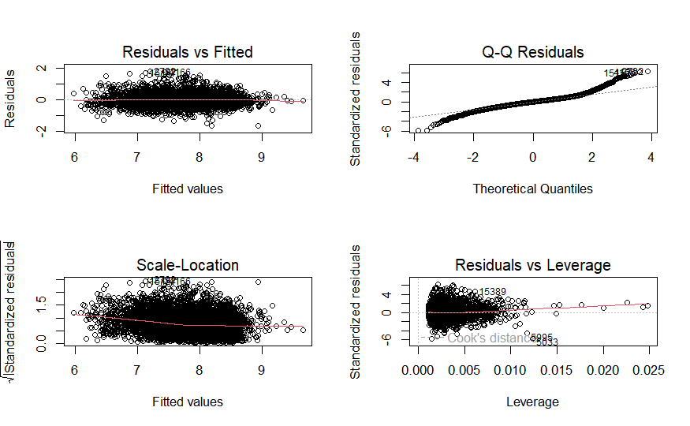

```r
par(mfrow=c(2,2))
plot(minnlandlog)
```

```
             Test stat Pr(>|Test stat|)
region
improvements    6.5550        5.880e-11 ***
yearF
acres           8.1345        4.704e-16 ***
tillable       11.2921        < 2.2e-16 ***
financing
crpPct          2.8609         0.004234 **
productivity    9.9328        < 2.2e-16 ***
Tukey test     -2.3775         0.017430 *
---
Signif. codes:  0 ‘***’ 0.001 ‘**’ 0.01 ‘*’ 0.05 ‘.’ 0.1 ‘ ’ 1
```

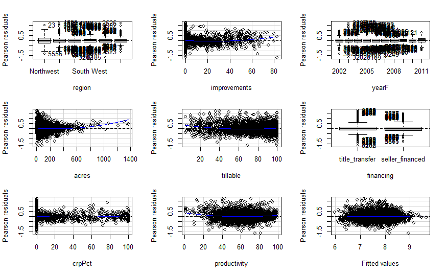

```r
residualPlots(minnlandlog)
```

```r
resettest(minnlandlog, power = 2:3, type = "regressor")
```

```
    RESET test

data:  minnlandlog
RESET = 46.076, df1 = 10, df2 = 8739, p-value < 2.2e-16
```

```r
ncvTest(minnlandlog)
```

```
Non-constant Variance Score Test
Variance formula: ~ fitted.values
Chisquare = 624.2331, Df = 1, p = < 2.22e-16
```

```r
bptest(minnlandlog)
```

```
    studentized Breusch-Pagan test

data:  minnlandlog
BP = 1049.1, df = 20, p-value < 2.2e-16
```

```r
vif(minnlandlog)
```

```
                 GVIF Df GVIF^(1/(2*Df))
region       1.527367  5        1.043264
improvements 1.146972  1        1.070968
yearF        1.047161  9        1.002563
acres        1.051228  1        1.025294
tillable     1.289205  1        1.135432
financing    1.003614  1        1.001805
crpPct       1.061724  1        1.030400
productivity 1.596788  1        1.263641
```

```r
outlierTest(minnlandlog)
```

|  | rstudent | unadjusted p-value | Bonferroni p |
| --- | --- | --- | --- |
| 2792 | 6.260477 | 4.0186e-10 | 3.5243e-06 |
| 4166 | 6.021810 | 1.7943e-09 | 1.5736e-05 |
| 15157 | 5.939859 | 2.9616e-09 | 2.5973e-05 |
| 17579 | -5.821162 | 6.0500e-09 | 5.3058e-05 |
| 5033 | -5.803747 | 6.7108e-09 | 5.8854e-05 |
| 2848 | 5.695257 | 1.2717e-08 | 1.1153e-04 |
| 14027 | 5.484054 | 4.2727e-08 | 3.7472e-04 |
| 15290 | 5.444737 | 5.3287e-08 | 4.6733e-04 |
| 13830 | 5.344005 | 9.3204e-08 | 8.1740e-04 |
| 13846 | 5.339373 | 9.5609e-08 | 8.3849e-04 |

We see that several of our assumptions are violated. Linearity, homoscedasticity, normality, and we even have some outliers. This tells us that, as it is, this is not a good model. However, we are looking to see which model is better between and our other one that we will build. Before we do so, we want to look at the anova table to see if all those predictor variables truly are significant.

```r
anova(minnlandlog)
```

```
Analysis of Variance Table

Response: log(acrePrice)
               Df Sum Sq Mean Sq  F value    Pr(>F)
region          5 894.16 178.831 2156.947 < 2.2e-16 ***
improvements    1  60.00  60.003  723.722 < 2.2e-16 ***
yearF           9 767.86  85.318 1029.052 < 2.2e-16 ***
acres           1   2.14   2.137   25.780 3.905e-07 ***
tillable        1  78.69  78.692  949.138 < 2.2e-16 ***
financing       1   3.33   3.332   40.193 2.414e-10 ***
crpPct          1  39.65  39.648  478.206 < 2.2e-16 ***
productivity    1  85.88  85.882 1035.856 < 2.2e-16 ***
Residuals    8749 725.37   0.083
---
Signif. codes:  0 ‘***’ 0.001 ‘**’ 0.01 ‘*’ 0.05 ‘.’ 0.1 ‘ ’ 1
```

For the next model, we will be doing everything the same, the only difference is that we will apply a square root on the response rather than a log transformation.

```r
minnlandsqrt <- lm(sqrt(acrePrice)~region+improvements+yearF+acres+tillable+financing+crpPct+productivity, data = MinnLand)

summary(minnlandsqrt)
```

```
Call:
lm(formula = sqrt(acrePrice) ~ region + improvements + yearF +
    acres + tillable + financing + crpPct + productivity, data = MinnLand)

Residuals:
    Min      1Q  Median      3Q     Max
-46.202  -4.361  -0.444   3.619  61.728

Coefficients:
                           Estimate Std. Error t value Pr(>|t|)
(Intercept)               2.2340273  0.7879007   2.835 0.004587 **
regionWest Central       12.2572739  0.3388086  36.178  < 2e-16 ***
regionCentral            19.3610165  0.3762916  51.452  < 2e-16 ***
regionSouth West         15.2006840  0.3410842  44.566  < 2e-16 ***
regionSouth Central      18.6455582  0.3659253  50.955  < 2e-16 ***
regionSouth East         19.7148707  0.4236290  46.538  < 2e-16 ***
improvements              0.4400631  0.0100607  43.741  < 2e-16 ***
yearF2003                 1.9760957  0.5369707   3.680 0.000235 ***
yearF2004                 6.5280764  0.5302575  12.311  < 2e-16 ***
yearF2005                10.2828904  0.5240300  19.623  < 2e-16 ***
yearF2006                11.1886354  0.5248428  21.318  < 2e-16 ***
yearF2007                14.2041393  0.5233265  27.142  < 2e-16 ***
yearF2008                20.4279550  0.5125792  39.853  < 2e-16 ***
yearF2009                20.5963278  0.5460588  37.718  < 2e-16 ***
yearF2010                24.4145809  0.5410501  45.124  < 2e-16 ***
yearF2011                25.7669527  0.6025357  42.764  < 2e-16 ***
acres                    -0.0084370  0.0009611  -8.778  < 2e-16 ***
tillable                  0.0815238  0.0059317  13.744  < 2e-16 ***
financingseller_financed -1.4868142  0.2701840  -5.503 3.84e-08 ***
crpPct                   -0.0835068  0.0062624 -13.335  < 2e-16 ***
productivity              0.2323938  0.0077518  29.979  < 2e-16 ***
---
Signif. codes:  0 ‘***’ 0.001 ‘**’ 0.01 ‘*’ 0.05 ‘.’ 0.1 ‘ ’ 1

Residual standard error: 7.743 on 8749 degrees of freedom
  (9930 observations deleted due to missingness)
Multiple R-squared:  0.6863,    Adjusted R-squared:  0.6855
F-statistic: 956.8 on 20 and 8749 DF,  p-value: < 2.2e-16
```

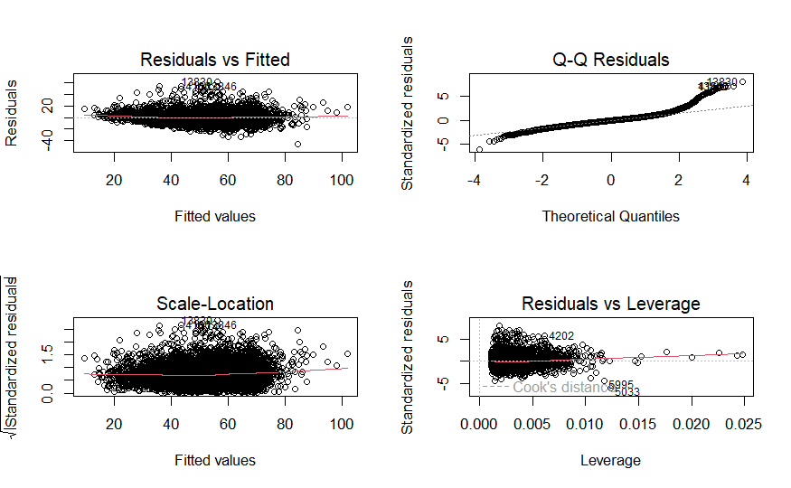

```r
par(mfrow=c(2,2))
plot(minnlandsqrt)
```

```r
residualPlots(minnlandsqrt)
```

```
             Test stat Pr(>|Test stat|)
region
improvements    7.1549        9.049e-13 ***
yearF
acres           7.8152        6.124e-15 ***
tillable       10.8720        < 2.2e-16 ***
financing
crpPct          3.6652        0.0002486 ***
productivity   12.0238        < 2.2e-16 ***
Tukey test     14.3364        < 2.2e-16 ***
---
Signif. codes:  0 ‘***’ 0.001 ‘**’ 0.01 ‘*’ 0.05 ‘.’ 0.1 ‘ ’ 1
```

```r
resettest(minnlandsqrt, power = 2:3, type = "regressor")
```

```
    RESET test

data:  minnlandsqrt
RESET = 47.981, df1 = 10, df2 = 8739, p-value < 2.2e-16
```

```r
ncvTest(minnlandsqrt)
```

```
Non-constant Variance Score Test
Variance formula: ~ fitted.values
Chisquare = 39.00269, Df = 1, p = 4.2322e-10
```

```r
bptest(minnlandsqrt)
```

```
    studentized Breusch-Pagan test

data:  minnlandsqrt
BP = 705.73, df = 20, p-value < 2.2e-16
```

```r
vif(minnlandsqrt)
```

```
                 GVIF Df GVIF^(1/(2*Df))
region       1.527367  5        1.043264
improvements 1.146972  1        1.070968
yearF        1.047161  9        1.002563
acres        1.051228  1        1.025294
tillable     1.289205  1        1.135432
financing    1.003614  1        1.001805
crpPct       1.061724  1        1.030400
productivity 1.596788  1        1.263641
```

```r
outlierTest(minnlandsqrt)
```

|  | rstudent | unadjusted p-value | Bonferroni p |
| --- | --- | --- | --- |
| 13830 | 8.008269 | 1.3124e-15 | 1.1510e-11 |
| 13846 | 7.056608 | 1.8361e-12 | 1.6103e-08 |
| 4166 | 7.023296 | 2.3289e-12 | 2.0424e-08 |
| 2792 | 7.007679 | 2.6025e-12 | 2.2824e-08 |
| 13840 | 6.939184 | 4.2243e-12 | 3.7047e-08 |
| 15328 | 6.873453 | 6.6957e-12 | 5.8721e-08 |
| 13878 | 6.725066 | 1.8652e-11 | 1.6358e-07 |
| 13856 | 6.680882 | 2.5201e-11 | 2.2101e-07 |
| 4233 | 6.586897 | 4.7501e-11 | 4.1659e-07 |
| 15290 | 6.414264 | 1.4884e-10 | 1.3053e-06 |

```r
anova(minnlandsqrt)
```

```
Analysis of Variance Table

Response: sqrt(acrePrice)
               Df Sum Sq Mean Sq  F value    Pr(>F)
region          5 468282   93656 1562.106 < 2.2e-16 ***
improvements    1  58135   58135  969.641 < 2.2e-16 ***
yearF           9 503723   55969  933.517 < 2.2e-16 ***
acres           1   2272    2272   37.890 7.815e-10 ***
tillable        1  37913   37913  632.352 < 2.2e-16 ***
financing       1   2245    2245   37.444 9.810e-10 ***
crpPct          1  20906   20906  348.690 < 2.2e-16 ***
productivity    1  53885   53885  898.750 < 2.2e-16 ***
Residuals    8749 524548      60
---
Signif. codes:  0 ‘***’ 0.001 ‘**’ 0.01 ‘*’ 0.05 ‘.’ 0.1 ‘ ’ 1
```

Other than the metrics posted, everything is practically the same. We violate the same assumptions and the anova is telling is the same variables that matter, all of them. Now for the next section, this is where we will be applying a 5 cross-fold validation method with prediction to show which model is better based soley on predictions. In order for it to work properly, we must eliminate all NA values in order for our method to work. Our data set will decrease by about 10,000 observations.

```r
MinnLand2 <- na.omit(MinnLand)

set.seed(519)

MinnLand2$sampid <- rep(5, dim(MinnLand2)[1])

set <- sample(dim(MinnLand2)[1], dim(MinnLand2)[1], replace=FALSE)
for(i in 1:5){
  MinnLand2$sampid[set[(i-1)*1754+1:(i*1754)]] = i
}

foreach(i = 1:5, .combine = "+") %do% {
  sets = which(MinnLand2$sampid == i)
  logmod <- lm(log(acrePrice)~region+improvements+yearF+acres+tillable+financing+crpPct+productivity,     data=MinnLand2[-sets,])
  preds <- predict(logmod, newdata=MinnLand2[sets,])
  y_true <- log(MinnLand2$acrePrice[sets])
  sum((y_true - preds)^2)
}
```

```
[1] 729.0704
```

Here we see that our Resisual Sum of Squares combined is about 729.07. Now we will do the same with the square root version of the model and see how the Resisual Sum of Squares performs, keep in mind we can also use the Mean Squared Error, which is just the RSS divided by the observation amount.

```r
set.seed(520)

MinnLand2$sampid <- rep(5, dim(MinnLand2)[1])

set <- sample(dim(MinnLand2)[1], dim(MinnLand2)[1], replace = FALSE)
for(i in 1:5){
  MinnLand2$sampid[set[(i-1)*1754+1:(i*1754)]] = i
}

foreach(i = 1:5, .combine = "+") %do% {
  sets = which(MinnLand2$sampid == i)
  sqrtmod <- lm(sqrt(acrePrice)~region+improvements+yearF+acres+tillable+financing+crpPct+productivity,
  data=MinnLand2[-sets,])
  preds <- predict(sqrtmod, newdata=MinnLand2[sets,])
  y_true <- sqrt(MinnLand2$acrePrice[sets])
  sum((y_true - preds)^2)
}
```

```
[1] 527775.8
```

We can clearly see the value of the RSS for the log is significantly smaller than the RSS for the square root model, letting us know that our log model predicts far better. We can do the same thing, this time with 10-fold cross validation to see if our results will be any different.

```r
set.seed(521)

MinnLand2$sampid <- rep(10, dim(MinnLand2)[1])

set <- sample(dim(MinnLand2)[1], dim(MinnLand2)[1], replace = FALSE)
for(i in 1:10){
  MinnLand2$sampid[set[(i-1)*877+1:(i*877)]] = i
}

foreach(i = 1:10, .combine ="+") %do% {
  sets = which(MinnLand2$sampid == i)
  logmod2 <- lm(log(acrePrice)~region+improvements+yearF+acres+tillable+financing+crpPct+productivity,    data=MinnLand2[-sets,])
  preds <- predict(logmod2, newdata=MinnLand2[sets,])
  y_true <- log(MinnLand2$acrePrice[sets])
  sum((y_true - preds)^2)

}
```

```
[1] 730.4112
```

```r
set.seed(522)

MinnLand2$sampid <- rep(10, dim(MinnLand2)[1])

set <- sample(dim(MinnLand2)[1], dim(MinnLand2)[1], replace = FALSE)
for(i in 1:10){
  MinnLand2$sampid[set[(i-1)*877+1:(i*877)]] = i
}

foreach(i = 1:10, .combine="+") %do% {
  sets = which(MinnLand2$sampid == i)
  sqrtmod2 <- lm(sqrt(acrePrice)~region+improvements+yearF+acres+tillable+financing+crpPct+productivity,   data = MinnLand2[-sets,])
  preds <- predict(sqrtmod2, newdata = MinnLand2[sets,])
  y_true <- sqrt(MinnLand2$acrePrice[sets])
  sum((y_true - preds)^2)
}
```

```
[1] 527793.9
```

Once again, we see that the log model performs better. Even in 10-fold cross validation the residual sum of squares for the log model is a fraction of the square-root model, further indicating to us that the log model is far better than the square root model just based off of prediction capabilities.

The last method of cross validation we are going to look at is the simple train and test split, which is just a basic version of the k-fold cross validation, however we will be taking multiple permutations of the values to get an overall average.

```r
detectCores()
```

```
[1] 12
```

```r
cl <- makeCluster(6)
registerDoParallel(cl)
getDoParWorkers()
```

```
[1] 6
```

```r
set.seed(523)

foreach(i = 1:1000, .combine="+", .options.RNG = 523) %dopar% {
  set = sample(dim(MinnLand2)[1], 6000, replace = FALSE)
  logsimp <- lm(log(acrePrice)~region+improvements+yearF+acres+tillable+financing+crpPct+productivity,    data=MinnLand2[set,])
  preds <- predict(logsimp, newdata=MinnLand2[-set,])
  y_true <- log(MinnLand2$acrePrice[-set])
  sum((y_true - preds)^2)
}
```

```
[1] 230772.1
```

Now we see that our RSS is a lot bigger for the log model. That is usually the case when you do random splitting as opposed to k-fold cross validation. Finally I am going to do the same, but this time with the square root version. We then will compare the metric scores before finally deciding on a model and doing our analysis from there.

```r
set.seed(524)

foreach(i = 1:1000, .combine = "+", .options.RNG = 524) %dopar% {
  set = sample(dim(MinnLand2)[1], 6000, replace = FALSE)
  sqrtsimp <- lm(sqrt(acrePrice)~region+improvements+yearF+acres+tillable+financing+crpPct+productivity,   data = MinnLand2[set,])
  preds <- predict(sqrtsimp, newdata = MinnLand2[-set,])
  y_true <- sqrt(MinnLand2$acrePrice[-set])
  sum((y_true - preds)^2)
}
```

```
[1] 166703962
```

Once again, the log residual sum of squares is far smaller than the square root residual sum of squares. We can safely go with the log model, as that has had better prediction accuracy every sinlge time we compared the two models no matter what cross validation method we introduced.

```r
summary(minnlandlog)
```

```
Call:
lm(formula = log(acrePrice) ~ region + improvements + yearF +
    acres + tillable + financing + crpPct + productivity, data = MinnLand)

Residuals:
     Min       1Q   Median       3Q      Max
-1.67184 -0.15615  0.00066  0.14573  1.79680

Coefficients:
                           Estimate Std. Error t value Pr(>|t|)
(Intercept)               5.631e+00  2.930e-02 192.176  < 2e-16 ***
regionWest Central        6.376e-01  1.260e-02  50.603  < 2e-16 ***
regionCentral             8.971e-01  1.399e-02  64.107  < 2e-16 ***
regionSouth West          7.401e-01  1.268e-02  58.352  < 2e-16 ***
regionSouth Central       8.664e-01  1.361e-02  63.671  < 2e-16 ***
regionSouth East          9.062e-01  1.575e-02  57.526  < 2e-16 ***
improvements              1.573e-02  3.741e-04  42.042  < 2e-16 ***
yearF2003                 8.286e-02  1.997e-02   4.149 3.37e-05 ***
yearF2004                 2.908e-01  1.972e-02  14.749  < 2e-16 ***
yearF2005                 4.528e-01  1.949e-02  23.236  < 2e-16 ***
yearF2006                 4.959e-01  1.952e-02  25.406  < 2e-16 ***
yearF2007                 6.183e-01  1.946e-02  31.772  < 2e-16 ***
yearF2008                 8.342e-01  1.906e-02  43.763  < 2e-16 ***
yearF2009                 8.413e-01  2.031e-02  41.430  < 2e-16 ***
yearF2010                 9.601e-01  2.012e-02  47.720  < 2e-16 ***
yearF2011                 9.982e-01  2.241e-02  44.551  < 2e-16 ***
acres                    -2.934e-04  3.574e-05  -8.208 2.57e-16 ***
tillable                  4.029e-03  2.206e-04  18.263  < 2e-16 ***
financingseller_financed -5.692e-02  1.005e-02  -5.665 1.51e-08 ***
crpPct                   -3.752e-03  2.329e-04 -16.110  < 2e-16 ***
productivity              9.278e-03  2.883e-04  32.185  < 2e-16 ***
---
Signif. codes:  0 ‘***’ 0.001 ‘**’ 0.01 ‘*’ 0.05 ‘.’ 0.1 ‘ ’ 1

Residual standard error: 0.2879 on 8749 degrees of freedom
  (9930 observations deleted due to missingness)
Multiple R-squared:  0.727, Adjusted R-squared:  0.7264
F-statistic:  1165 on 20 and 8749 DF,  p-value: < 2.2e-16
```